# EDA before Prediction

ElenaKush

March 29, 2020

## Executive summary

One thing that people regularly do is quantify how much of a particular activity they do, but they rarely quantify how well they do it. In this project, our goal was to predict the manner in which 6 people did the barbell lifts. We used data from accelerometers on the belt, forearm, arm, and dumbell of 6 people, who were asked to perform barbell lifts in 5 different fashions:

exactly according to the specification (class A),

throwing the elbows to the front (class B),

lifting the dumbbell only halfway (class C),

lowering the dumbbell only halfway (class D)

throwing the hips to the front (class E).

In this part we will perform a deep explorative data analysis in order to understand the nature of data.

SUMMARY:

1. Both training and test sets have 160 variables.
2. Many numeric variable are assign to factors which may affect the model quality.
3. The aggregates are placed at the end of the window, in the rows where new_window == ‘yes’. Most of aggregates are factors. Aggregates can be excluded for sophisticated models, such as decision trees or random forest.
4. The observations in a training set are clearly sorted by a target variable. For the training there is a need to exclude the X variable which indicates the number of observation (row in the dataset).
5. Each user was performing the exercises in the same order (A -> B -> C -> D -> E).
6. Each user performed the exercises in a very short period of time, so the timestamps for different users do not overlap each other.
7. These two findings (s. 5, 6) show the way of dataset preparation and can lead to leakage in predictions. So, it might be nessecary to exclude timestamp for the fair training purposes.
8. Within one window there can be observed only one class. So it means, if one observation from the window is used for testing and all other observations from the same window are used for the training, the variable num_window should be a good predictor. For the fair validation strategy, we have to place to a test set all observations from one or several windows, so there will be no leakage.
9. For the project purposes (s. 8), we inspected the distribution of num_window in the ‘hidden’ test set and checked whether the observations in it are picked from one window and this window is excluded from the train set. We figured out that in the test set, each observation corresponds to a unique window. And all other observations from this window are included into a training set. So, the proposed validation strategy can not be considered as a fair one. But we need to follow it for the project purposes.
10. For the project purposes, we need to simulate similar validation strategy. So, we refuse from the fair strategy and will randomly pick observations for my_test_set.
11. The target variable can be considered as a balanced one. There is no need to generate new data to get a more balanced dataset.

## Environment settings

```r
if("pacman" %in% rownames(installed.packages()) == FALSE){ install.packages("pacman") }
library(pacman)
p_load(caret,
       dplyr,
       tidyr,
       lubridate,
       reshape2,
       ggplot2,
       plotly,
       ranger)
```

## Data Loading

```r
local_path <- "C:/Users/kushnarevaei/Documents/GitHub/JH_R_Course/Course8/Week4/project8/"

download.file("https://d396qusza40orc.cloudfront.net/predmachlearn/pml-training.csv",
              destfile = "data/train_set.csv")
download.file("https://d396qusza40orc.cloudfront.net/predmachlearn/pml-testing.csv",
              destfile = "data/test_set.csv")

train_set <- read.csv(paste0(local_path,"data/train_set.csv"))
test_set <- read.csv(paste0(local_path,"data/test_set.csv"))
```

## Dataset structure

```r
dim(train_set)
```

```
[1] 19622   160
```

```r
dim(test_set)
```

```
[1]  20 160
```

```r
str(train_set) ## many numeric variable are in fact factors which may affect the model quality
```

```
'data.frame':   19622 obs. of  160 variables:
 $ X                       : int  1 2 3 4 5 6 7 8 9 10 ...
 $ user_name               : Factor w/ 6 levels "adelmo","carlitos",..: 2 2 2 2 2 2 2 2 2 2 ...
 $ raw_timestamp_part_1    : int  1323084231 1323084231 1323084231 1323084232 1323084232 1323084232 1323084232 1323084232 1323084232 1323084232 ...
 $ raw_timestamp_part_2    : int  788290 808298 820366 120339 196328 304277 368296 440390 484323 484434 ...
 $ cvtd_timestamp          : Factor w/ 20 levels "02/12/2011 13:32",..: 9 9 9 9 9 9 9 9 9 9 ...
 $ new_window              : Factor w/ 2 levels "no","yes": 1 1 1 1 1 1 1 1 1 1 ...
 $ num_window              : int  11 11 11 12 12 12 12 12 12 12 ...
 $ roll_belt               : num  1.41 1.41 1.42 1.48 1.48 1.45 1.42 1.42 1.43 1.45 ...
 $ pitch_belt              : num  8.07 8.07 8.07 8.05 8.07 8.06 8.09 8.13 8.16 8.17 ...
 $ yaw_belt                : num  -94.4 -94.4 -94.4 -94.4 -94.4 -94.4 -94.4 -94.4 -94.4 -94.4 ...
 $ total_accel_belt        : int  3 3 3 3 3 3 3 3 3 3 ...
 $ kurtosis_roll_belt      : Factor w/ 397 levels "","-0.016850",..: 1 1 1 1 1 1 1 1 1 1 ...
 $ kurtosis_picth_belt     : Factor w/ 317 levels "","-0.021887",..: 1 1 1 1 1 1 1 1 1 1 ...
 $ kurtosis_yaw_belt       : Factor w/ 2 levels "","#DIV/0!": 1 1 1 1 1 1 1 1 1 1 ...
```

[output cut: 86 more lines]

```r
class(train_set$kurtosis_picth_belt) ## the numeric variables have factor class instead of numeric
```

```
[1] "factor"
```

```r
summary(train_set)
```

```
       X            user_name    raw_timestamp_part_1 raw_timestamp_part_2
 Min.   :    1   adelmo  :3892   Min.   :1.322e+09    Min.   :   294
 1st Qu.: 4906   carlitos:3112   1st Qu.:1.323e+09    1st Qu.:252912
 Median : 9812   charles :3536   Median :1.323e+09    Median :496380
 Mean   : 9812   eurico  :3070   Mean   :1.323e+09    Mean   :500656
 3rd Qu.:14717   jeremy  :3402   3rd Qu.:1.323e+09    3rd Qu.:751891
 Max.   :19622   pedro   :2610   Max.   :1.323e+09    Max.   :998801

          cvtd_timestamp  new_window    num_window      roll_belt
 28/11/2011 14:14: 1498   no :19216   Min.   :  1.0   Min.   :-28.90
 05/12/2011 11:24: 1497   yes:  406   1st Qu.:222.0   1st Qu.:  1.10
 30/11/2011 17:11: 1440               Median :424.0   Median :113.00
 05/12/2011 11:25: 1425               Mean   :430.6   Mean   : 64.41
 02/12/2011 14:57: 1380               3rd Qu.:644.0   3rd Qu.:123.00
 02/12/2011 13:34: 1375               Max.   :864.0   Max.   :162.00
 (Other)         :11007
   pitch_belt          yaw_belt       total_accel_belt kurtosis_roll_belt
 Min.   :-55.8000   Min.   :-180.00   Min.   : 0.00             :19216
 1st Qu.:  1.7600   1st Qu.: -88.30   1st Qu.: 3.00    #DIV/0!  :   10
 Median :  5.2800   Median : -13.00   Median :17.00    -1.908453:    2
 Mean   :  0.3053   Mean   : -11.21   Mean   :11.31    -0.016850:    1
 3rd Qu.: 14.9000   3rd Qu.:  12.90   3rd Qu.:18.00    -0.021024:    1
 Max.   : 60.3000   Max.   : 179.00   Max.   :29.00    -0.025513:    1
                                                       (Other)  :  391
 kurtosis_picth_belt kurtosis_yaw_belt skewness_roll_belt skewness_roll_belt.1
          :19216            :19216              :19216             :19216
 #DIV/0!  :   32     #DIV/0!:  406     #DIV/0!  :    9    #DIV/0!  :   32
 47.000000:    4                       0.000000 :    4    0.000000 :    4
 -0.150950:    3                       0.422463 :    2    -2.156553:    3
 -0.684748:    3                       -0.003095:    1    -3.072669:    3
 -1.750749:    3                       -0.010002:    1    -6.324555:    3
 (Other)  :  361                       (Other)  :  389    (Other)  :  361
 skewness_yaw_belt max_roll_belt     max_picth_belt   max_yaw_belt
        :19216     Min.   :-94.300   Min.   : 3.00          :19216
 #DIV/0!:  406     1st Qu.:-88.000   1st Qu.: 5.00   -1.1   :   30
                   Median : -5.100   Median :18.00   -1.4   :   29
                   Mean   : -6.667   Mean   :12.92   -1.2   :   26
                   3rd Qu.: 18.500   3rd Qu.:19.00   -0.9   :   24
                   Max.   :180.000   Max.   :30.00   -1.3   :   22
                   NA's   :19216     NA's   :19216   (Other):  275
```

[output cut: 280 more lines]

```
 gyros_forearm_y     gyros_forearm_z    accel_forearm_x   accel_forearm_y
 Min.   : -7.02000   Min.   : -8.0900   Min.   :-498.00   Min.   :-632.0
 1st Qu.: -1.46000   1st Qu.: -0.1800   1st Qu.:-178.00   1st Qu.:  57.0
 Median :  0.03000   Median :  0.0800   Median : -57.00   Median : 201.0
 Mean   :  0.07517   Mean   :  0.1512   Mean   : -61.65   Mean   : 163.7
 3rd Qu.:  1.62000   3rd Qu.:  0.4900   3rd Qu.:  76.00   3rd Qu.: 312.0
 Max.   :311.00000   Max.   :231.0000   Max.   : 477.00   Max.   : 923.0

 accel_forearm_z   magnet_forearm_x  magnet_forearm_y magnet_forearm_z classe
 Min.   :-446.00   Min.   :-1280.0   Min.   :-896.0   Min.   :-973.0   A:5580
 1st Qu.:-182.00   1st Qu.: -616.0   1st Qu.:   2.0   1st Qu.: 191.0   B:3797
 Median : -39.00   Median : -378.0   Median : 591.0   Median : 511.0   C:3422
 Mean   : -55.29   Mean   : -312.6   Mean   : 380.1   Mean   : 393.6   D:3216
 3rd Qu.:  26.00   3rd Qu.:  -73.0   3rd Qu.: 737.0   3rd Qu.: 653.0   E:3607
 Max.   : 291.00   Max.   :  672.0   Max.   :1480.0   Max.   :1090.0
```

SUMMARY:

1. Both training and test sets have 160 variables.
2. Many numeric variable are assign to factors which may affect the model quality.

Let’s check that the dataset structures are identical in the training and testing sets.

```r
cl <- NULL
for (i in names(train_set)) {
    cl <- rbind(cl, class(train_set$i) == class(test_set$i))
}
sum(cl)
```

```
[1] 160
```

```r
names(train_set) == names(test_set)
```

```
  [1]  TRUE  TRUE  TRUE  TRUE  TRUE  TRUE  TRUE  TRUE  TRUE  TRUE  TRUE  TRUE
 [13]  TRUE  TRUE  TRUE  TRUE  TRUE  TRUE  TRUE  TRUE  TRUE  TRUE  TRUE  TRUE
 [25]  TRUE  TRUE  TRUE  TRUE  TRUE  TRUE  TRUE  TRUE  TRUE  TRUE  TRUE  TRUE
 [37]  TRUE  TRUE  TRUE  TRUE  TRUE  TRUE  TRUE  TRUE  TRUE  TRUE  TRUE  TRUE
 [49]  TRUE  TRUE  TRUE  TRUE  TRUE  TRUE  TRUE  TRUE  TRUE  TRUE  TRUE  TRUE
 [61]  TRUE  TRUE  TRUE  TRUE  TRUE  TRUE  TRUE  TRUE  TRUE  TRUE  TRUE  TRUE
 [73]  TRUE  TRUE  TRUE  TRUE  TRUE  TRUE  TRUE  TRUE  TRUE  TRUE  TRUE  TRUE
 [85]  TRUE  TRUE  TRUE  TRUE  TRUE  TRUE  TRUE  TRUE  TRUE  TRUE  TRUE  TRUE
 [97]  TRUE  TRUE  TRUE  TRUE  TRUE  TRUE  TRUE  TRUE  TRUE  TRUE  TRUE  TRUE
[109]  TRUE  TRUE  TRUE  TRUE  TRUE  TRUE  TRUE  TRUE  TRUE  TRUE  TRUE  TRUE
[121]  TRUE  TRUE  TRUE  TRUE  TRUE  TRUE  TRUE  TRUE  TRUE  TRUE  TRUE  TRUE
[133]  TRUE  TRUE  TRUE  TRUE  TRUE  TRUE  TRUE  TRUE  TRUE  TRUE  TRUE  TRUE
[145]  TRUE  TRUE  TRUE  TRUE  TRUE  TRUE  TRUE  TRUE  TRUE  TRUE  TRUE  TRUE
[157]  TRUE  TRUE  TRUE FALSE
```

```r
names(train_set[160])
```

```
[1] "classe"
```

```r
names(test_set[160])
```

```
[1] "problem_id"
```

## Variable meaning

Let’s check what is the meaning and correlation between num_window and new_window variables.

In many columns, there are aggregates like avg, std, var, etc. of the movements within the window. It seems, those aggregates are stored in the rows where new_window == “yes”.

Let’s check it.

```r
train_set[1:25, c(2, 6, 7, 160)]
```

```
   user_name new_window num_window classe
1   carlitos         no         11      A
2   carlitos         no         11      A
3   carlitos         no         11      A
4   carlitos         no         12      A
5   carlitos         no         12      A
6   carlitos         no         12      A
7   carlitos         no         12      A
8   carlitos         no         12      A
9   carlitos         no         12      A
10  carlitos         no         12      A
11  carlitos         no         12      A
12  carlitos         no         12      A
13  carlitos         no         12      A
14  carlitos         no         12      A
15  carlitos         no         12      A
16  carlitos         no         12      A
17  carlitos         no         12      A
18  carlitos         no         12      A
19  carlitos         no         12      A
20  carlitos         no         12      A
21  carlitos         no         12      A
22  carlitos         no         12      A
23  carlitos         no         12      A
24  carlitos        yes         12      A
25  carlitos         no         13      A
```

Let’s subtract only the observations where the new_window == ‘yes’ and check whether there are values in the aggregates ‘max_roll_belt’ and ‘kurtosis_picth_belt’.

```r
new_wndw <- which(train_set$new_window == "yes")
max_r_b <- which(!is.na(train_set$max_roll_belt))
kurt_p_b <- which(train_set$kurtosis_picth_belt != "")
```

Let’s do a formal test (the rows with new_window == yes are correspond to the filled rows in max_roll_belt and kurtosis_picth_belt.

```r
summary(new_wndw - max_r_b)
```

```
   Min. 1st Qu.  Median    Mean 3rd Qu.    Max.
      0       0       0       0       0       0
```

```r
summary(new_wndw - kurt_p_b)
```

```
   Min. 1st Qu.  Median    Mean 3rd Qu.    Max.
      0       0       0       0       0       0
```

```r
train_set %>%
##    filter(new_window == "yes") %>%
    filter(new_window == "no") %>%
    group_by(user_name) %>%
    summarise(
        cnt = n(),
        filledIn = sum(!is.na(max_roll_belt))
        ) %>%
    View
```

The aggregates are placed at the end of the window, in the rows where new_window == ‘yes’.

Let’s check whether the target variable can be changed within one window.

```r
spread_df <- train_set %>%
  count(classe, num_window) %>%
  spread(classe, n, fill = 0)

spread_df$sum <- rowSums(spread_df[, -1])

View(spread_df)
spread_df$dif <- 0
for(i in 1:nrow(spread_df)) {
    if (spread_df[i, 2] != 0) {
      spread_df$dif[i] <- spread_df[i, 2] - spread_df[i, 7]
      } else if (spread_df[i, 3] != 0) {
          spread_df$dif[i] <- spread_df[i, 3] - spread_df[i, 7]
          } else if (spread_df[i, 4] != 0) {
              spread_df$dif[i] <- spread_df[i, 4] - spread_df[i, 7]
          } else if (spread_df[i, 5] != 0) {
              spread_df$dif[i] <- spread_df[i, 5] - spread_df[i, 7]
          } else if (spread_df[i, 6] != 0) {
              spread_df$dif[i] <- spread_df[i, 6] - spread_df[i, 7]
                      } else {
                          spread_df$dif <- NULL
                      }
}
summary(unlist(spread_df$dif))
```

```
   Min. 1st Qu.  Median    Mean 3rd Qu.    Max.
      0       0       0       0       0       0
```

The target variable is the same within one window.

Let’s check how many observations and windows are collected per each user and how many observations are collected per each window.

```r
train_set %>%
    group_by(user_name) %>%
    summarise(
        cnt = n(),
        cnt_wndw = length(unique(num_window))
        ) %>%
    View

wind_stat <- train_set %>%
    group_by(user_name, num_window) %>%
    summarise(
        cnt = n()
        )
summary(wind_stat)
```

```
    user_name     num_window         cnt
 adelmo  :177   Min.   :  1.0   Min.   : 1.00
 carlitos:130   1st Qu.:217.2   1st Qu.:20.00
 charles :158   Median :431.5   Median :23.00
 eurico  :130   Mean   :432.1   Mean   :22.87
 jeremy  :146   3rd Qu.:646.8   3rd Qu.:27.00
 pedro   :117   Max.   :864.0   Max.   :38.00
```

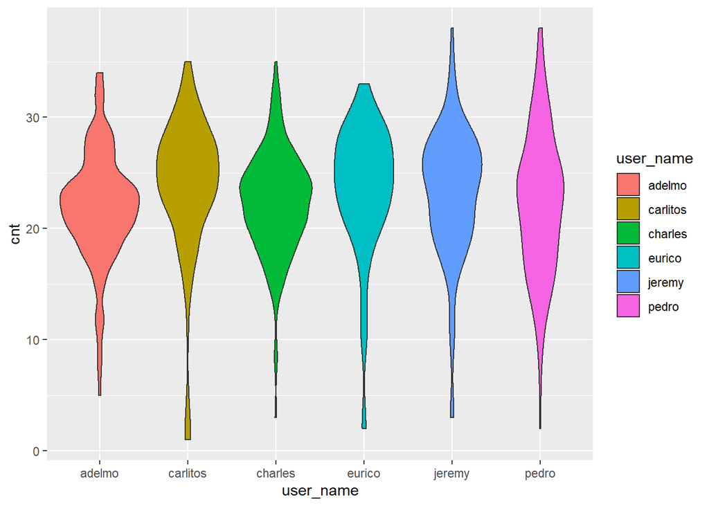

```r
ggplot(data = wind_stat, aes(x = user_name, y = cnt, fill = user_name)) +
  geom_violin()
```

SUMMARY:

1. The aggregates are placed at the end of the window, in the rows where new_window == ‘yes’.
2. There are about 23 observation in each window.
3. Within one window only one class be observed. So it means, if one observation from the window is used for testing and all other observations from the same window are used for the training, the variable num_window should be a good predictor. For the fair validation strategy, we have to place to a test set all observations from one or several windows, so there will be no leakage. But for the project purposes, we should inspect the ‘hidden’ test set and check whether the observations in it are picked from one window and this window is excluded from the train set.

## Test set inspection

We are not going to look at the target but we would like to check the distribution of users and windows in the test set.

```r
test_set %>%
    group_by(num_window) %>%
    summarise(cnt = n())
```

```
# A tibble: 20 x 2
   num_window   cnt
        <int> <int>
 1         48     1
 2         72     1
 3         74     1
 4        194     1
 5        235     1
 6        255     1
 7        257     1
 8        302     1
 9        323     1
10        361     1
11        408     1
12        431     1
13        439     1
14        440     1
15        461     1
16        485     1
17        504     1
18        664     1
19        779     1
20        859     1
```

SUMMARY:

1. In the test set, each observation corresponds to a unique window.
2. For the project purposes, we need to simulate similar validation strategy as proposed by authors. So, we refuse from the fair strategy and randomly pick observations for my_test_set.

## Distribution of target variable

Finally, in order to choose an appropriate model type and validation strategy, we need to figure out whether we have a balanced or imbalanced dataset.

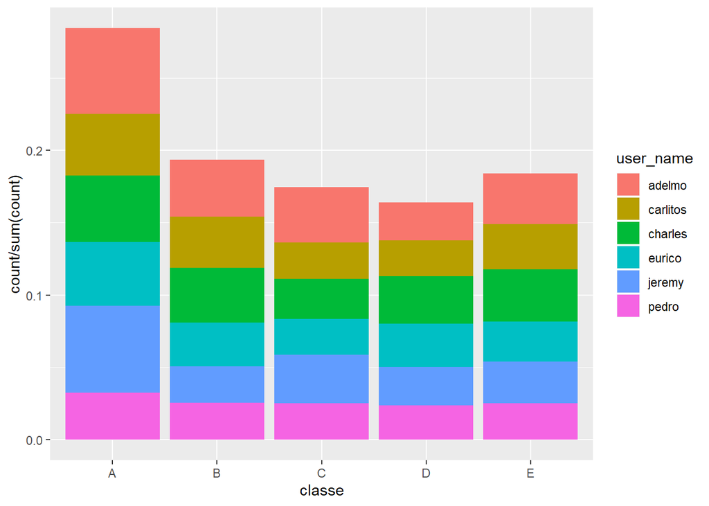

```r
ggplot(data = train_set, aes(x = classe, fill = user_name)) +
    geom_bar(aes(y = ..count../sum(..count..)))
```

SUMMARY:

1. The target variable can be considered as a balanced one.There is no need to generate new data to get a more balanced dataset.

## Sorting of the observations

Let’s check the sorting of observations.

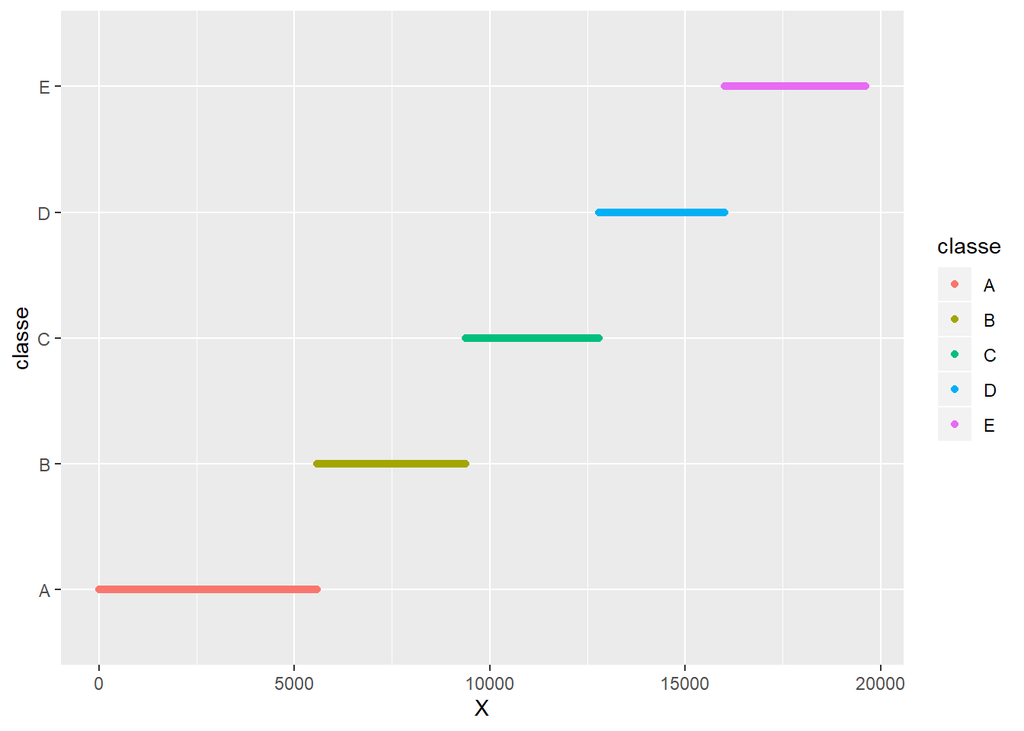

```r
ggplot(data = train_set, aes(x = X, y = classe, color = classe)) + ## by classe
  geom_point()
```

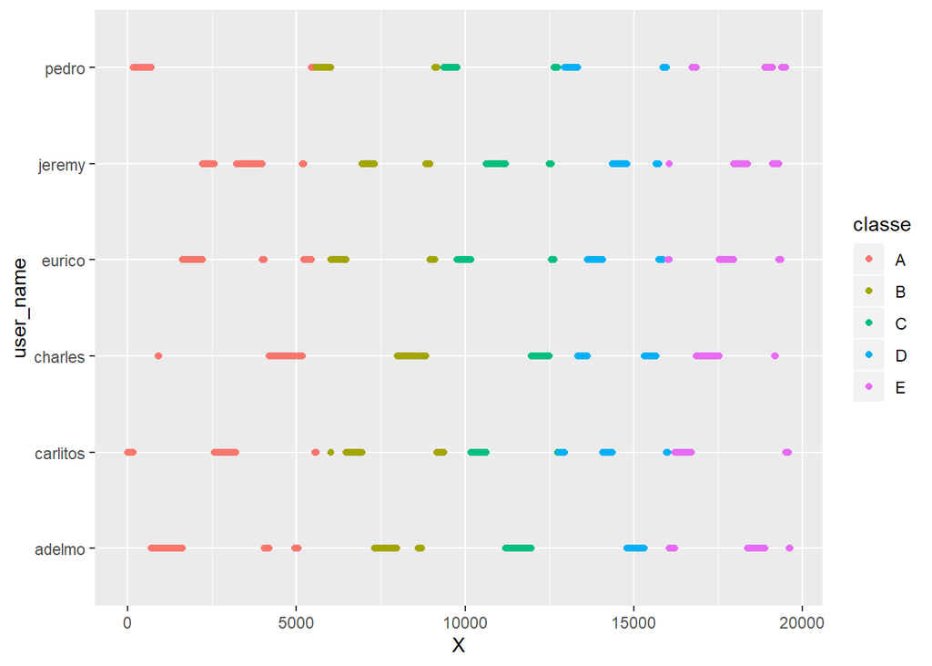

```r
ggplot(data = train_set, aes(x = X, y = user_name, color = classe)) + ## by user_name
  geom_point()
```

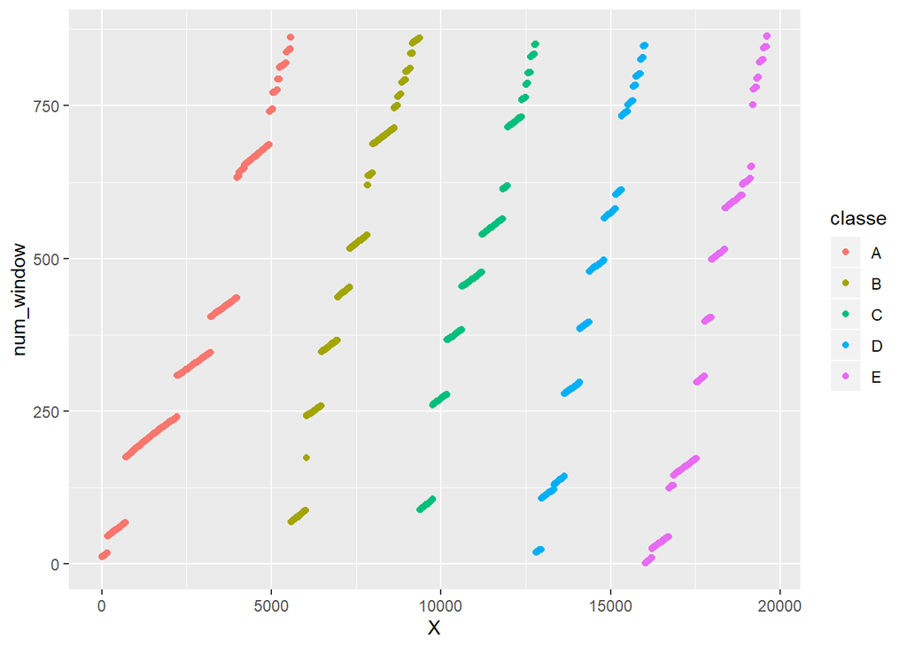

```r
ggplot(data = train_set, aes(x = X, y = num_window, color = classe)) + ## by num_window
  geom_point()
```

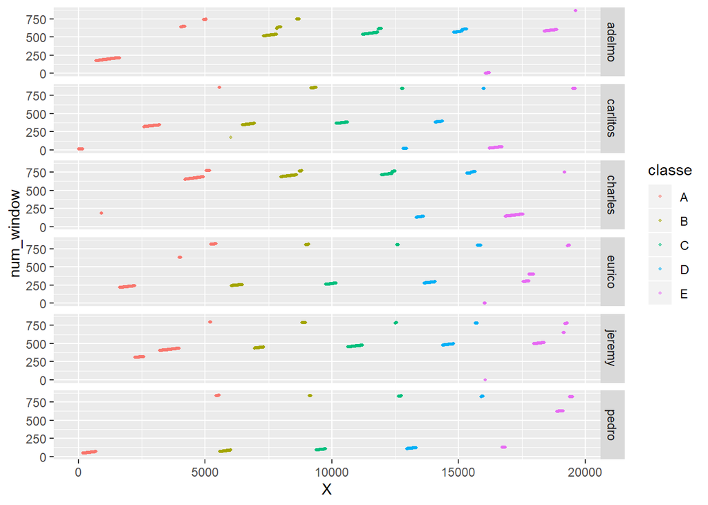

```r
ggplot(data = train_set, aes(x = X, y = num_window, color = classe)) + ## by num_window и user_name
  geom_point(alpha = 0.5, size = 0.8) +
    facet_grid(user_name ~ .)
```

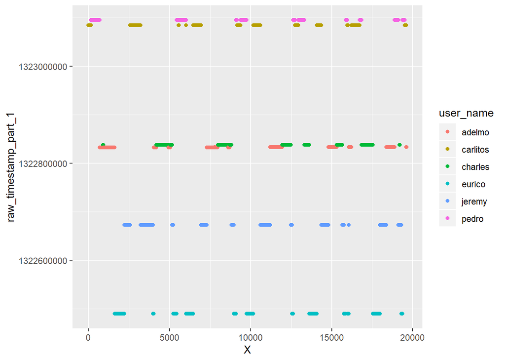

```r
ggplot(data = train_set, aes(x = X, y = raw_timestamp_part_1, color = user_name)) + ## by raw_timestamp_part_1
  geom_point()
```

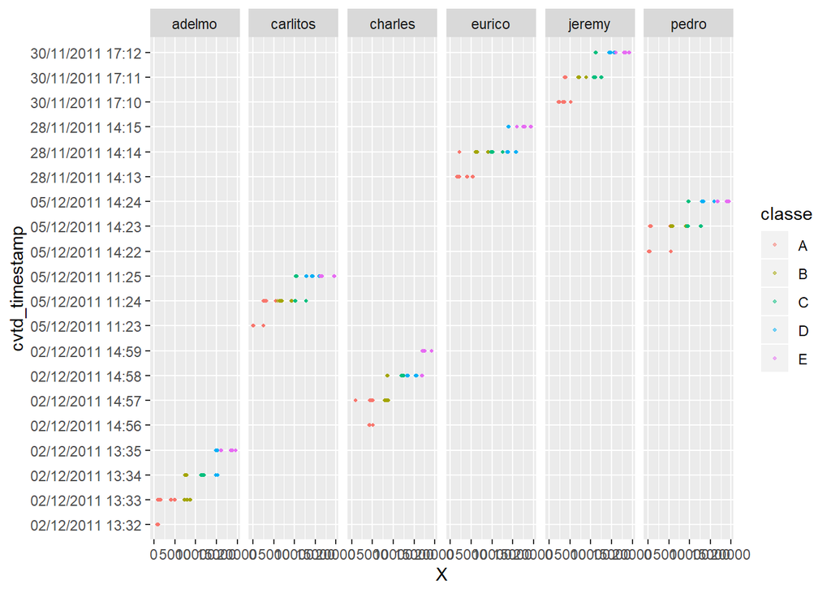

```r
ggplot(data = train_set, aes(x = X, y = cvtd_timestamp, color = classe)) + ## by cvtd_timestamp
  geom_point(alpha = 0.5, size = 0.8) +
    facet_grid(. ~ user_name)
```

[figure not shown]

```r
ggplot(data = train_set, aes(x = num_window, y = cvtd_timestamp, color = classe)) + ## num_window by cvtd_timestamp
  geom_point(alpha = 0.5, size = 0.8) +
    facet_grid(user_name ~ .)
```

SUMMARY:

1. Each user was performing the exercises in the same order (A -> B -> C -> D -> E).
2. Each user performed the exercises in a very short period of time, so the timestamps for different users do not overlap each other.
3. These two findings (the way of dataset preparation) can lead to leakage in predictions. So, there is a need to exclude timestamp from the training dataset.
4. The observations are clearly sorted by a target variable. For the training there is a need to exclude the X variable which indicates the number of observation (row in the dataset).

## Variable correlation

Let’s see the correlation between all columns (except the aggregates).

```r
trunc_train_set <- train_set[, c(1:11, 37:49, 60:68, 84:86, 102, 113:124, 140, 151:160)] ## subtract the factor variables (which are mostly the aggregates)

str(trunc_train_set)
```

```
'data.frame':   19622 obs. of  60 variables:
 $ X                   : int  1 2 3 4 5 6 7 8 9 10 ...
 $ user_name           : Factor w/ 6 levels "adelmo","carlitos",..: 2 2 2 2 2 2 2 2 2 2 ...
 $ raw_timestamp_part_1: int  1323084231 1323084231 1323084231 1323084232 1323084232 1323084232 1323084232 1323084232 1323084232 1323084232 ...
 $ raw_timestamp_part_2: int  788290 808298 820366 120339 196328 304277 368296 440390 484323 484434 ...
 $ cvtd_timestamp      : Factor w/ 20 levels "02/12/2011 13:32",..: 9 9 9 9 9 9 9 9 9 9 ...
 $ new_window          : Factor w/ 2 levels "no","yes": 1 1 1 1 1 1 1 1 1 1 ...
 $ num_window          : int  11 11 11 12 12 12 12 12 12 12 ...
 $ roll_belt           : num  1.41 1.41 1.42 1.48 1.48 1.45 1.42 1.42 1.43 1.45 ...
 $ pitch_belt          : num  8.07 8.07 8.07 8.05 8.07 8.06 8.09 8.13 8.16 8.17 ...
 $ yaw_belt            : num  -94.4 -94.4 -94.4 -94.4 -94.4 -94.4 -94.4 -94.4 -94.4 -94.4 ...
 $ total_accel_belt    : int  3 3 3 3 3 3 3 3 3 3 ...
 $ gyros_belt_x        : num  0 0.02 0 0.02 0.02 0.02 0.02 0.02 0.02 0.03 ...
 $ gyros_belt_y        : num  0 0 0 0 0.02 0 0 0 0 0 ...
 $ gyros_belt_z        : num  -0.02 -0.02 -0.02 -0.03 -0.02 -0.02 -0.02 -0.02 -0.02 0 ...
```

[output cut: 46 more lines]

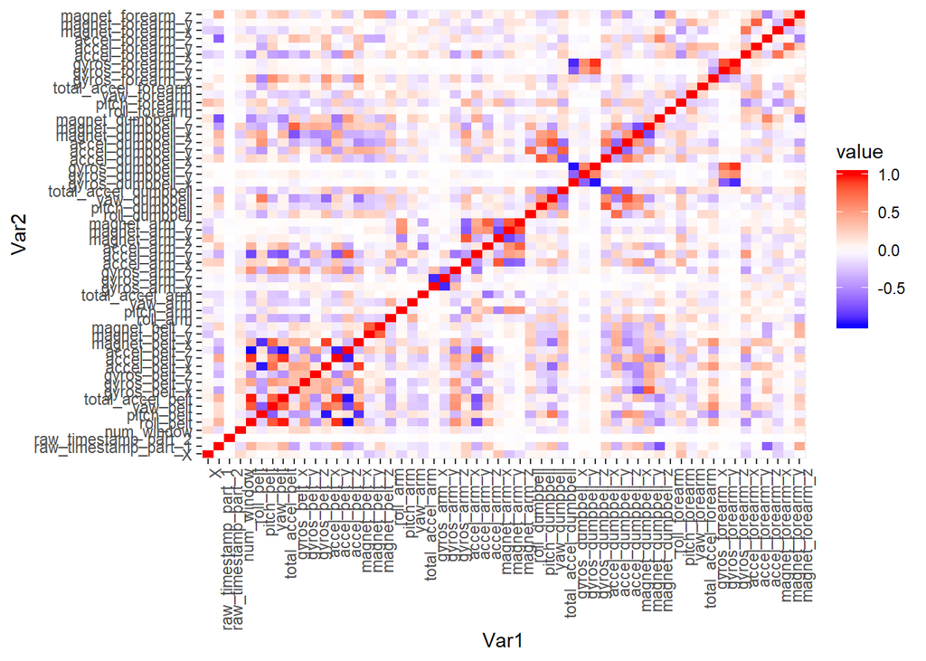

```r
cor_train <- cor(trunc_train_set[, sapply(trunc_train_set, is.numeric)], use = "complete.obs")
melted_cor_train <- melt(cor_train)

ggplot(data = melted_cor_train, aes(x=Var1, y=Var2, fill=value)) +
  geom_tile() +
    scale_fill_gradient2(low = "blue", high = "red", mid = "white") +
    theme(axis.text.x = element_text(angle = 90, hjust = 1))
```